# Residual_Diagnosis

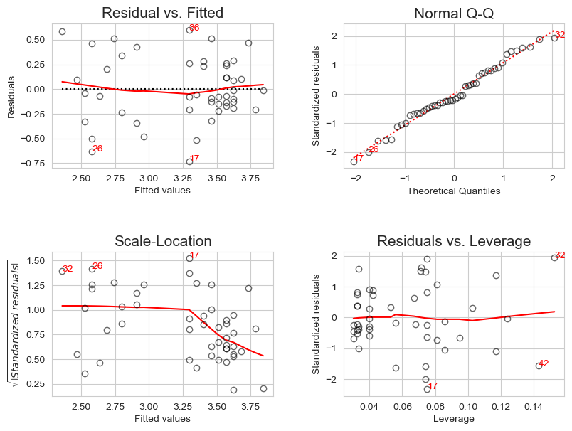

- **Residuals vs Fitted plot:** This plot is used to check if the residuals exhibit non-linear patterns. If the red line across the center of the plot is roughly horizontal then we can assume that the residuals follow a linear pattern. In the case of our chosen model, the red line appears almost near horizontal. Hence the linear relationship is satisfied.
- **Q-Q plot:** This plot is used to determine if the residuals of the regression model are normally distributed. If the points in this plot fall roughly along a straight diagonal line, then we can assume the residuals are normally distributed. In the case our chosen model too, the line appears almost straight as a diagonal. Hence the residuals are normally distributed in this transformed model.
- **Scale-Location plot:** This plot is used to check the assumption of equal variance (also called “homoscedasticity”) among the residuals in our regression model. If the red line is roughly horizontal across the plot, then the assumption of equal variance is likely met. In our case, although the red line doesn't appear to be completely horizontal, however this is just an artifact of the pattern in the original residuals and not real evidence of non-constant variance. Note that there is little to no evidence of non-constant variance in the Residuals vs Fitted. We would likely declare that the assumption of equal variance is not violated in this case.
- **Residuals vs Leverage plot:** This plot is used to identify influential observations. If any points in this plot fall outside of Cook’s distance then it is an influential observation. In our case, although observation numbers 32, 42 and 17 are near the Cook's distance, but they are well within the limits. Hence we can conclude that there aren't any overly influential points.

Now let us create a Residual vs Fitted plots for each of our predictor variables to check for heteroscedasticity of residuals as below:

### Regression Plots for "student_faculty_ratio"

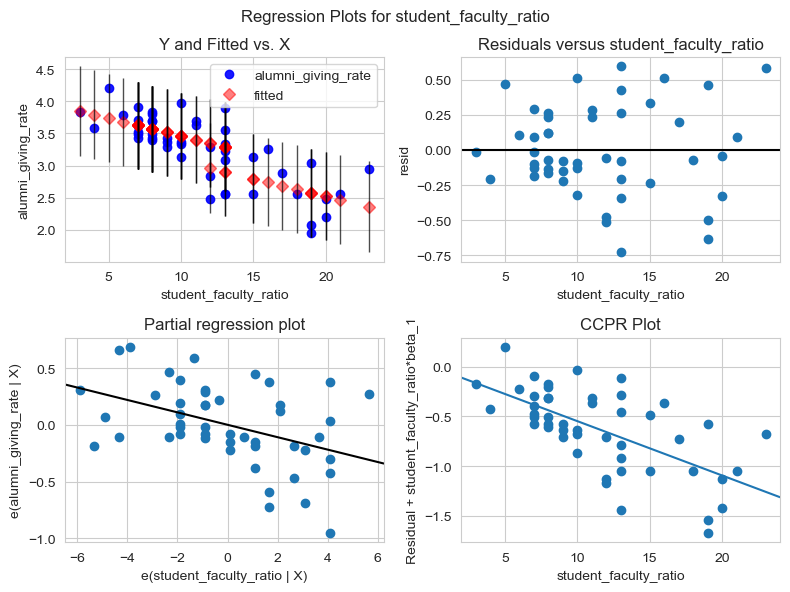

### Regression Plots for "private"

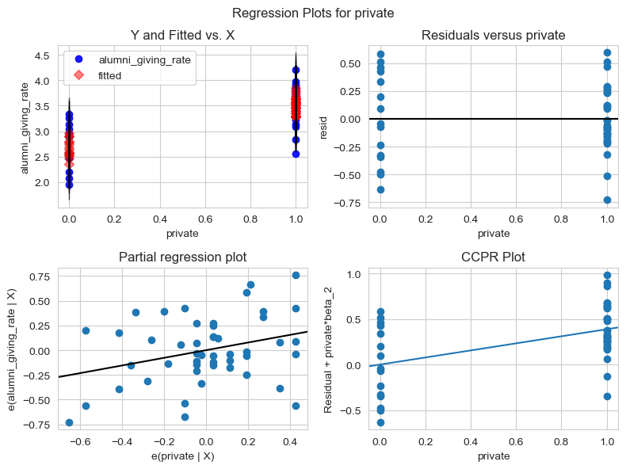

In the above plots, for both the predictor variables, the residuals appear to be randomly scattered, which is an indication that heteroscedasticity is not a problem with either predictor variable in the model. The regression plots for "private" appear to be in 2 straight lines as its values are binary throughout the distribution.